# Estudo sobre a qualidade de vida no Brasil entre 1991, 2000 e 2010

# Introdução

Este estudo mostra análises sobre as características demográficas da população brasileira durante a década de 90 e 2000. Foram utilizados os dados da PNUD (Pesquisa Nacional de Unidade Domiciliar).

# Medidas Descritivas

Foram utilizadas quatro variáveis para esta análise descritiva: Expectativa de Vida, Expectativa de anos de estudo até os 18 anos de idade, Renda per capita e população com água encanada. Estas variáveis foram analisadas nos anos de 1991, 2000 e 2010.

## Expectativa de Vida

### 1991

```r
library(dplyr);library(magrittr)
bs = read.csv("municipios.csv",header = T,sep=";",dec=",")
bs1991 = bs[bs["ano"] == 1991,]
summary(bs1991$espvida)
```

```
##    Min. 1st Qu.  Median    Mean 3rd Qu.    Max.
##   50.97   60.21   64.46   63.73   67.59   73.61
```

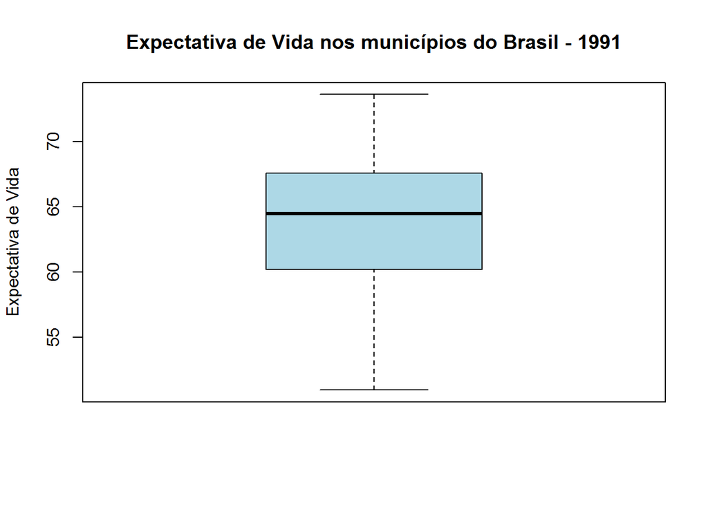

```r
boxplot(bs1991$espvida,col="Light Blue",main = "Expectativa de Vida nos municípios do Brasil - 1991",
        ylab = "Expectativa de Vida")
```

```r
arrange(bs1991[,c(238,5,6)],desc(bs1991$espvida))[1:3,]
```

|  | ufn | municipio | espvida |
| --- | --- | --- | --- |
| 1 | Santa Catarina | CUNHATAÍ | 73.61 |
| 2 | Santa Catarina | GUABIRUBA | 73.61 |
| 3 | Santa Catarina | MASSARANDUBA | 73.00 |

```r
arrange(bs1991[,c(238,5,6)],bs1991$espvida)[1:3,]
```

|  | ufn | municipio | espvida |
| --- | --- | --- | --- |
| 1 | Alagoas | SÃO JOSÉ DA TAPERA | 50.97 |
| 2 | Piauí | ILHA GRANDE | 51.18 |
| 3 | Paraíba | MARCAÇÃO | 51.26 |

```r
bs2 = read.csv("pnud.csv",header = T,sep=";",dec=",")
summary(bs2$espvida[bs2$ano==1991])
```

```
##    Min. 1st Qu.  Median    Mean 3rd Qu.    Max.
##   58.04   60.59   63.67   63.68   66.27   70.16
```

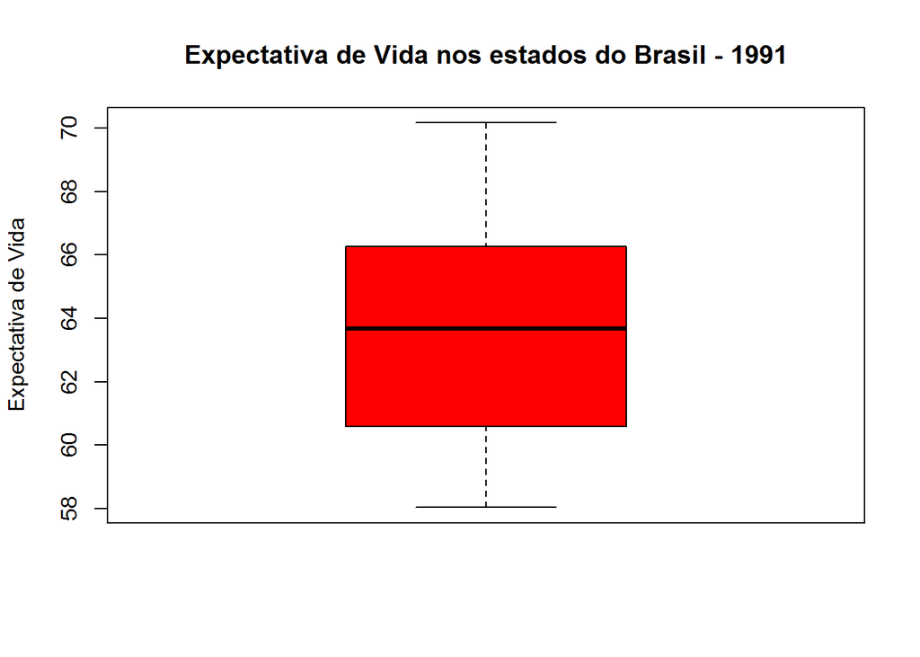

```r
boxplot(bs2$espvida[bs2$ano==1991],col = "Red",main = "Expectativa de Vida nos estados do Brasil - 1991",
        ylab = "Expectativa de Vida")
```

```r
arrange(bs2[bs2$ano==1991,3:4],desc(bs2$espvida[bs2$ano==1991]))[1:3,]
```

|  | ufn | espvida |
| --- | --- | --- |
| 1 | Santa Catarina | 70.16 |
| 2 | Distrito Federal | 68.87 |
| 3 | São Paulo | 68.82 |

```r
arrange(bs2[bs2$ano==1991,3:4],bs2$espvida[bs2$ano==1991])[1:3,]
```

|  | ufn | espvida |
| --- | --- | --- |
| 1 | Maranhão | 58.04 |
| 2 | Alagoas | 58.10 |
| 3 | Paraíba | 58.88 |

### 2000

```r
bs2000 = bs[bs["ano"] == 2000,]
summary(bs2000$espvida)
```

```
##    Min. 1st Qu.  Median    Mean 3rd Qu.    Max.
##   57.46   65.30   69.04   68.41   71.53   77.24
```

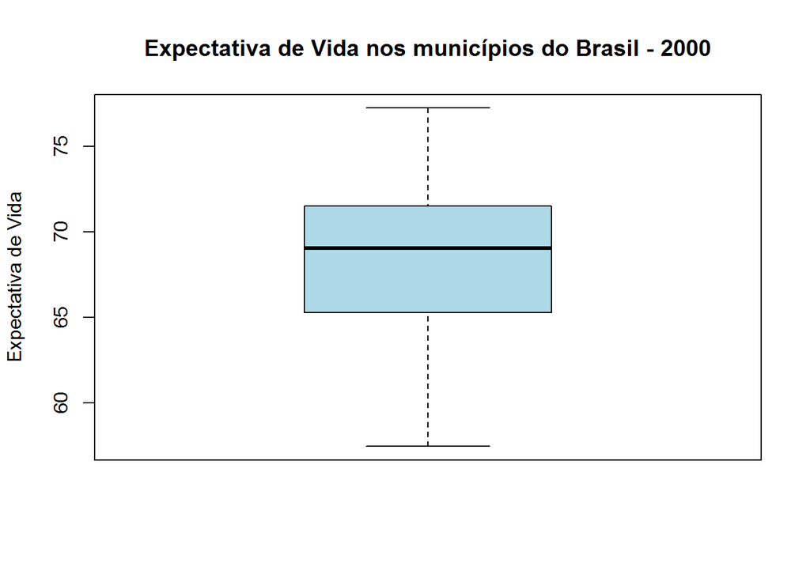

```r
boxplot(bs2000$espvida,col="Light Blue",main = "Expectativa de Vida nos municípios do Brasil - 2000",
        ylab = "Expectativa de Vida")
```

```r
arrange(bs2000[,c(238,5,6)],desc(bs2000$espvida))[1:3,]
```

|  | ufn | municipio | espvida |
| --- | --- | --- | --- |
| 1 | Santa Catarina | CUNHATAÍ | 77.24 |
| 2 | São Paulo | ÁGUAS DE SÃO PEDRO | 77.18 |
| 3 | São Paulo | SÃO CAETANO DO SUL | 77.18 |

```r
arrange(bs2000[,c(238,5,6)],bs2000$espvida)[1:3,]
```

|  | ufn | municipio | espvida |
| --- | --- | --- | --- |
| 1 | Alagoas | ROTEIRO | 57.46 |
| 2 | Bahia | VÁRZEA NOVA | 57.65 |
| 3 | Pernambuco | JUCATI | 57.81 |

```r
summary(bs2$espvida[bs2$ano==2000])
```

```
##    Min. 1st Qu.  Median    Mean 3rd Qu.    Max.
##   63.79   66.28   67.77   68.42   70.32   73.86
```

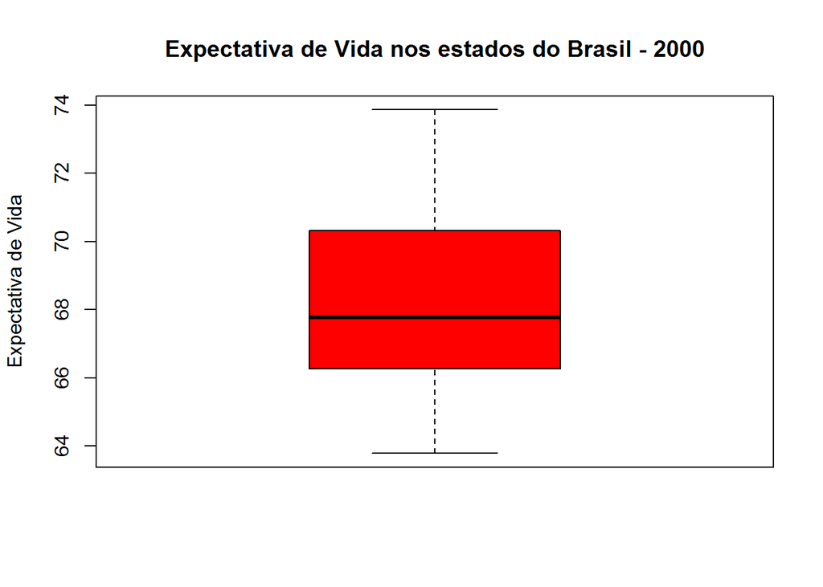

```r
boxplot(bs2$espvida[bs2$ano==2000],col = "Red",main = "Expectativa de Vida nos estados do Brasil - 2000",
        ylab = "Expectativa de Vida")
```

```r
arrange(bs2[bs2$ano==2000,3:4],desc(bs2$espvida[bs2$ano==2000]))[1:3,]
```

|  | ufn | espvida |
| --- | --- | --- |
| 1 | Distrito Federal | 73.86 |
| 2 | Santa Catarina | 73.69 |
| 3 | Rio Grande do Sul | 73.22 |

```r
arrange(bs2[bs2$ano==2000,3:4],bs2$espvida[bs2$ano==2000])[1:3,]
```

|  | ufn | espvida |
| --- | --- | --- |
| 1 | Alagoas | 63.79 |
| 2 | Maranhão | 63.92 |
| 3 | Paraíba | 65.34 |

### 2010

```r
bs2010 = bs[bs["ano"] == 2010,]
summary(bs2010$espvida)
```

```
##    Min. 1st Qu.  Median    Mean 3rd Qu.    Max.
##   65.30   71.15   73.47   73.09   75.16   78.64
```

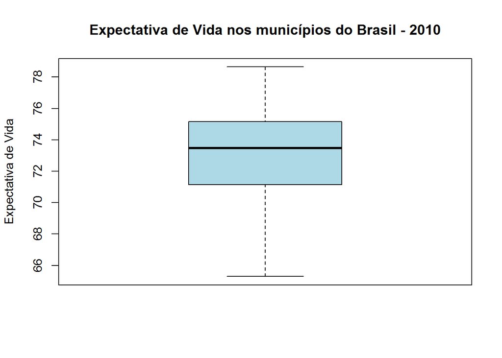

```r
boxplot(bs2010$espvida,col="Light Blue",main = "Expectativa de Vida nos municípios do Brasil - 2010",
        ylab = "Expectativa de Vida")
```

```r
arrange(bs2010[,c(238,5,6)],desc(bs2010$espvida))[1:3,]
```

|  | ufn | municipio | espvida |
| --- | --- | --- | --- |
| 1 | Santa Catarina | BLUMENAU | 78.64 |
| 2 | Santa Catarina | BRUSQUE | 78.64 |
| 3 | Santa Catarina | BALNEÁRIO CAMBORIÚ | 78.62 |

```r
arrange(bs2010[,c(238,5,6)],bs2010$espvida)[1:3,]
```

|  | ufn | municipio | espvida |
| --- | --- | --- | --- |
| 1 | Paraíba | CACIMBAS | 65.3 |
| 2 | Alagoas | ROTEIRO | 65.3 |
| 3 | Alagoas | OLHO D'ÁGUA GRANDE | 65.4 |

```r
summary(bs2$espvida[bs2$ano==2010])
```

```
##    Min. 1st Qu.  Median    Mean 3rd Qu.    Max.
##   70.32   72.16   73.30   73.51   75.03   77.35
```

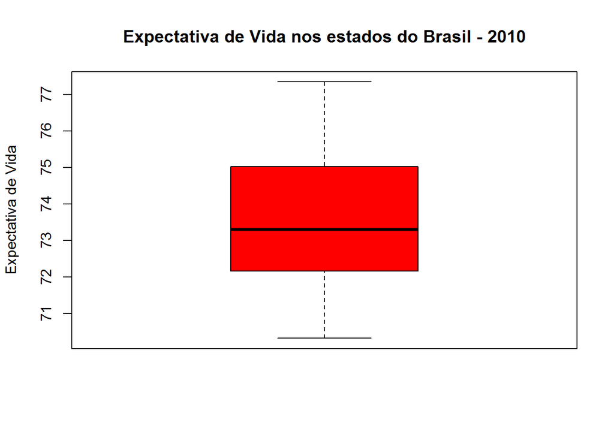

```r
boxplot(bs2$espvida[bs2$ano==2010],col = "Red",main = "Expectativa de Vida nos estados do Brasil - 2010",
        ylab = "Expectativa de Vida")
```

```r
arrange(bs2[bs2$ano==2010,3:4],desc(bs2$espvida[bs2$ano==2010]))[1:3,]
```

|  | ufn | espvida |
| --- | --- | --- |
| 1 | Distrito Federal | 77.35 |
| 2 | Santa Catarina | 76.61 |
| 3 | São Paulo | 75.69 |

```r
arrange(bs2[bs2$ano==2010,3:4],bs2$espvida[bs2$ano==2010])[1:3,]
```

|  | ufn | espvida |
| --- | --- | --- |
| 1 | Alagoas | 70.32 |
| 2 | Maranhão | 70.40 |
| 3 | Piauí | 71.62 |

Pode-se perceber que, ao longo dos anos, a melhora da qualidade de vida das pessoas aumentou a expectativa de vida das mesmas. Os estados da região Nordeste são os que as pessoas tem menor expectativa de vida, ao passo que na região Sul, a população costuma viver mais.

## Expectativa de anos de estudo até os 18 anos

### 1991

```r
summary(bs1991$e_anosestudo)
```

```
##    Min. 1st Qu.  Median    Mean 3rd Qu.    Max.
##   0.910   5.980   7.630   7.485   9.220  12.120
```

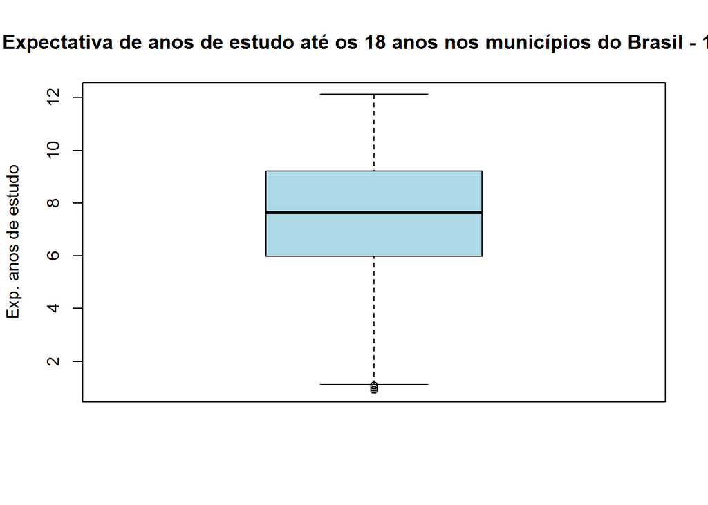

```r
boxplot(bs1991$e_anosestudo,col="Light Blue",main = "Expectativa de anos de estudo até os 18 anos nos municípios do Brasil - 1991",
        ylab = "Exp. anos de estudo")
```

```r
arrange(bs1991[,c(238,5,14)],desc(bs1991$e_anosestudo))[1:3,]
```

|  | ufn | municipio | e_anosestudo |
| --- | --- | --- | --- |
| 1 | Rio Grande do Sul | SANTO ANTÔNIO DO PLANALTO | 12.12 |
| 2 | Rio Grande do Sul | SERAFINA CORRÊA | 12.04 |
| 3 | Santa Catarina | MATOS COSTA | 11.98 |

```r
arrange(bs1991[,c(238,5,14)],bs1991$e_anosestudo)[1:3,]
```

|  | ufn | municipio | e_anosestudo |
| --- | --- | --- | --- |
| 1 | Bahia | CORONEL JOÃO SÁ | 0.91 |
| 2 | Pará | MELGAÇO | 0.99 |
| 3 | Maranhão | AFONSO CUNHA | 1.07 |

```r
summary(bs2$e_anosestudo[bs2$ano==1991])
```

```
##    Min. 1st Qu.  Median    Mean 3rd Qu.    Max.
##   5.750   6.465   7.550   7.683   8.605  10.250
```

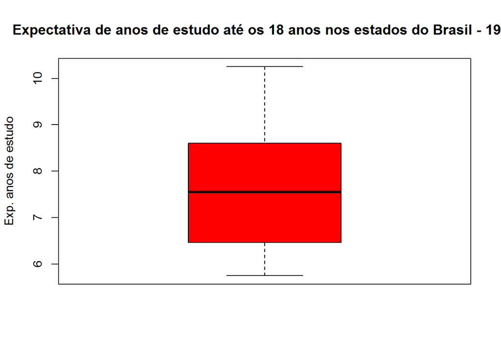

```r
boxplot(bs2$e_anosestudo[bs2$ano==1991],col = "Red",main = "Expectativa de anos de estudo até os 18 anos nos estados do Brasil - 1991",
        ylab = "Exp. anos de estudo")
```

```r
arrange(bs2[bs2$ano==1991,c(3,12)],desc(bs2$e_anosestudo[bs2$ano==1991]))[1:3,]
```

|  | ufn | e_anosestudo |
| --- | --- | --- |
| 1 | Rio Grande do Sul | 10.25 |
| 2 | Santa Catarina | 9.93 |
| 3 | São Paulo | 9.68 |

```r
arrange(bs2[bs2$ano==1991,c(3,12)],bs2$e_anosestudo[bs2$ano==1991])[1:3,]
```

|  | ufn | e_anosestudo |
| --- | --- | --- |
| 1 | Bahia | 5.75 |
| 2 | Piauí | 5.89 |
| 3 | Paraíba | 6.21 |

### 2000

```r
summary(bs2000$e_anosestudo)
```

```
##    Min. 1st Qu.  Median    Mean 3rd Qu.    Max.
##   2.290   7.020   8.430   8.338   9.780  13.020
```

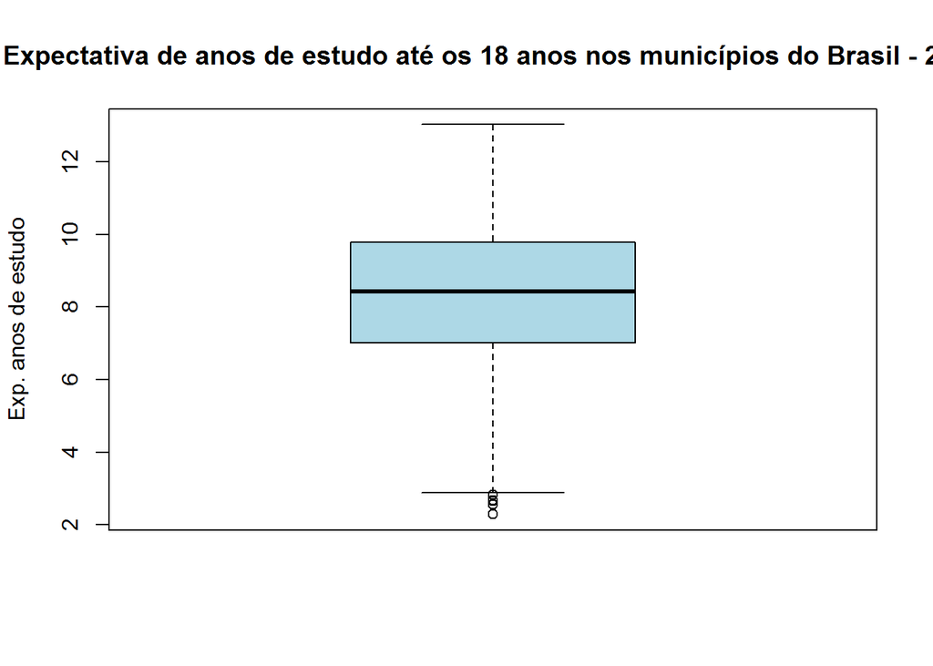

```r
boxplot(bs2000$e_anosestudo,col="Light Blue",main = "Expectativa de anos de estudo até os 18 anos nos municípios do Brasil - 2000",
        ylab = "Exp. anos de estudo")
```

```r
arrange(bs2000[,c(238,5,14)],desc(bs2000$e_anosestudo))[1:3,]
```

|  | ufn | municipio | e_anosestudo |
| --- | --- | --- | --- |
| 1 | Rio Grande do Sul | NICOLAU VERGUEIRO | 13.02 |
| 2 | Rio Grande do Sul | ALMIRANTE TAMANDARÉ DO SUL | 12.62 |
| 3 | São Paulo | NOVA CASTILHO | 12.59 |

```r
arrange(bs2000[,c(238,5,14)],bs2000$e_anosestudo)[1:3,]
```

|  | ufn | municipio | e_anosestudo |
| --- | --- | --- | --- |
| 1 | Pará | CHAVES | 2.29 |
| 2 | Acre | JORDÃO | 2.56 |
| 3 | Amazonas | UARINI | 2.65 |

```r
summary(bs2$e_anosestudo[bs2$ano==2000])
```

```
##    Min. 1st Qu.  Median    Mean 3rd Qu.    Max.
##   6.540   7.245   8.560   8.373   9.335  10.250
```

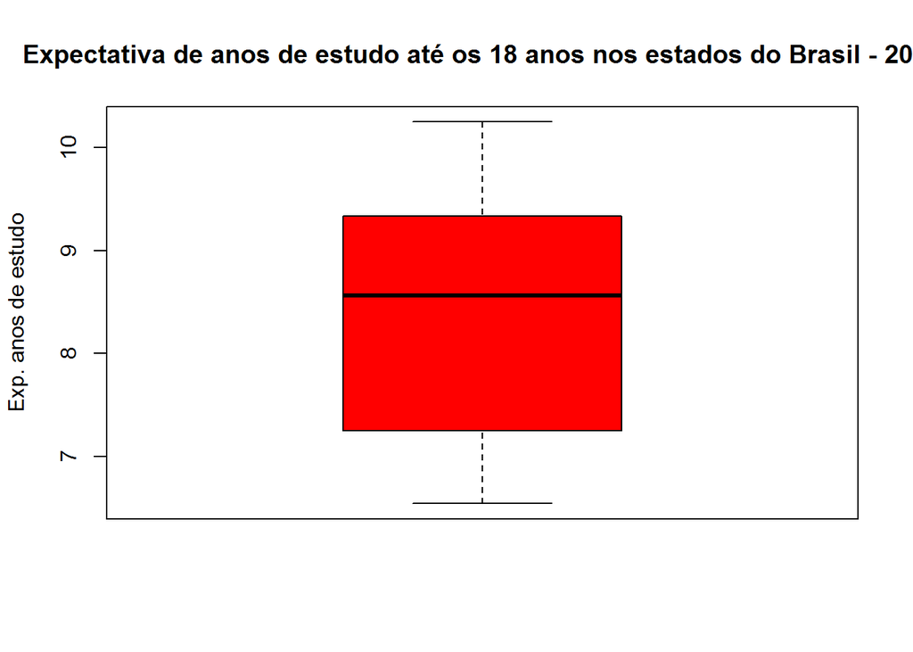

```r
boxplot(bs2$e_anosestudo[bs2$ano==2000],col = "Red",main = "Expectativa de anos de estudo até os 18 anos nos estados do Brasil - 2000",
        ylab = "Exp. anos de estudo")
```

```r
arrange(bs2[bs2$ano==2000,c(3,12)],desc(bs2$e_anosestudo[bs2$ano==2000]))[1:3,]
```

|  | ufn | e_anosestudo |
| --- | --- | --- |
| 1 | Rio Grande do Sul | 10.25 |
| 2 | São Paulo | 10.23 |
| 3 | Santa Catarina | 10.13 |

```r
arrange(bs2[bs2$ano==2000,c(3,12)],bs2$e_anosestudo[bs2$ano==2000])[1:3,]
```

|  | ufn | e_anosestudo |
| --- | --- | --- |
| 1 | Alagoas | 6.54 |
| 2 | Amazonas | 6.68 |
| 3 | Piauí | 6.68 |

### 2010

```r
summary(bs2010$e_anosestudo)
```

```
##    Min. 1st Qu.  Median    Mean 3rd Qu.    Max.
##   4.340   8.750   9.470   9.464  10.210  12.830
```

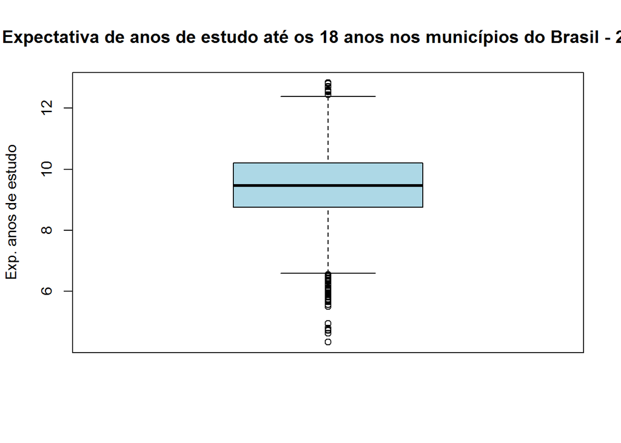

```r
boxplot(bs2010$e_anosestudo,col="Light Blue",main = "Expectativa de anos de estudo até os 18 anos nos municípios do Brasil - 2010",
        ylab = "Exp. anos de estudo")
```

```r
arrange(bs2010[,c(238,5,14)],desc(bs2010$e_anosestudo))[1:3,]
```

|  | ufn | municipio | e_anosestudo |
| --- | --- | --- | --- |
| 1 | Paraná | GODOY MOREIRA | 12.83 |
| 2 | Paraná | SANTO ANTÔNIO DO PARAÍSO | 12.80 |
| 3 | Rio Grande do Sul | SÃO JOSÉ DO INHACORÁ | 12.72 |

```r
arrange(bs2010[,c(238,5,14)],bs2010$e_anosestudo)[1:3,]
```

|  | ufn | municipio | e_anosestudo |
| --- | --- | --- | --- |
| 1 | Amazonas | BARCELOS | 4.34 |
| 2 | Amazonas | ATALAIA DO NORTE | 4.63 |
| 3 | Acre | SANTA ROSA DO PURUS | 4.72 |

```r
summary(bs2$e_anosestudo[bs2$ano==2010])
```

```
##    Min. 1st Qu.  Median    Mean 3rd Qu.    Max.
##   8.490   9.100   9.290   9.394   9.810  10.430
```

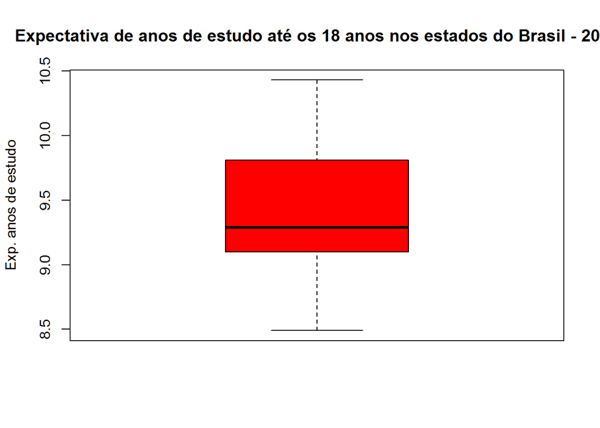

```r
boxplot(bs2$e_anosestudo[bs2$ano==2010],col = "Red",main = "Expectativa de anos de estudo até os 18 anos nos estados do Brasil - 2010",
        ylab = "Exp. anos de estudo")
```

```r
arrange(bs2[bs2$ano==2010,c(3,12)],desc(bs2$e_anosestudo[bs2$ano==2010]))[1:3,]
```

|  | ufn | e_anosestudo |
| --- | --- | --- |
| 1 | Paraná | 10.43 |
| 2 | São Paulo | 10.33 |
| 3 | Santa Catarina | 10.24 |

```r
arrange(bs2[bs2$ano==2010,c(3,12)],bs2$e_anosestudo[bs2$ano==2010])[1:3,]
```

|  | ufn | e_anosestudo |
| --- | --- | --- |
| 1 | Pará | 8.49 |
| 2 | Amazonas | 8.54 |
| 3 | Bahia | 8.63 |

Novamente, esta expectativa apresentou melhora significativa ao longo dos anos. Porém, algumas cidades das regiões Norte e Nordeste ainda apresentam índices fracos quanto à escolaridade.

## Renda per capita

### 1991

```r
summary(bs1991$rdpc)
```

```
##    Min. 1st Qu.  Median    Mean 3rd Qu.    Max.
##   33.24  119.97  200.74  234.83  314.70 1185.28
```

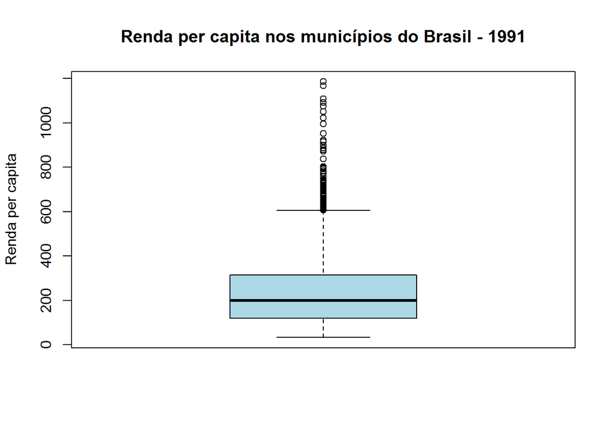

```r
boxplot(bs1991$rdpc,col="Light Blue",main = "Renda per capita nos municípios do Brasil - 1991",
        ylab = "Renda per capita")
```

```r
arrange(bs1991[,c(238,5,92)],desc(bs1991$rdpc))[1:3,]
```

|  | ufn | municipio | rdpc |
| --- | --- | --- | --- |
| 1 | São Paulo | ÁGUAS DE SÃO PEDRO | 1185.28 |
| 2 | São Paulo | SANTANA DE PARNAÍBA | 1167.62 |
| 3 | São Paulo | SÃO CAETANO DO SUL | 1107.53 |

```r
arrange(bs1991[,c(238,5,92)],bs1991$rdpc)[1:3,]
```

|  | ufn | municipio | rdpc |
| --- | --- | --- | --- |
| 1 | Maranhão | NOVA COLINAS | 33.24 |
| 2 | Pernambuco | SANTA FILOMENA | 39.45 |
| 3 | Piauí | LAGOA DE SÃO FRANCISCO | 41.37 |

```r
summary(bs2$rdpc[bs2$ano==1991])
```

```
##    Min. 1st Qu.  Median    Mean 3rd Qu.    Max.
##   156.5   242.0   345.8   365.8   435.2   916.0
```

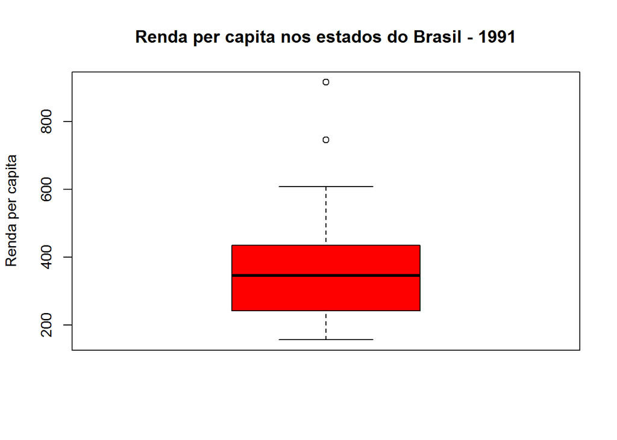

```r
boxplot(bs2$rdpc[bs2$ano==1991],col = "Red",main = "Renda per capita nos estados do Brasil - 1991",
        ylab = "Renda per capita")
```

```r
arrange(bs2[bs2$ano==1991,c(3,90)],desc(bs2$rdpc[bs2$ano==1991]))[1:3,]
```

|  | ufn | rdpc |
| --- | --- | --- |
| 1 | Distrito Federal | 916.00 |
| 2 | São Paulo | 746.22 |
| 3 | Rio de Janeiro | 608.80 |

```r
arrange(bs2[bs2$ano==1991,c(3,90)],bs2$rdpc[bs2$ano==1991])[1:3,]
```

|  | ufn | rdpc |
| --- | --- | --- |
| 1 | Maranhão | 156.47 |
| 2 | Piauí | 167.03 |
| 3 | Paraíba | 196.59 |

### 2000

```r
summary(bs2000$rdpc)
```

```
##    Min. 1st Qu.  Median    Mean 3rd Qu.    Max.
##   62.65  173.49  308.58  338.54  463.20 1759.76
```

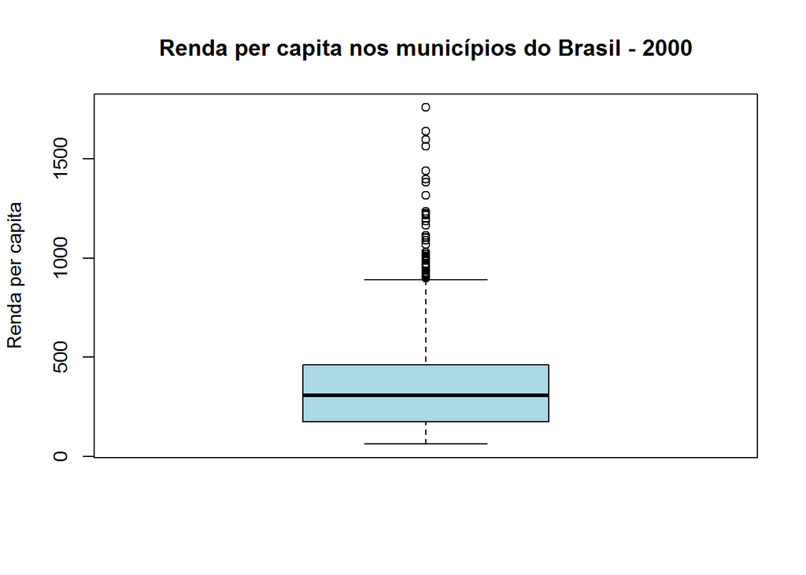

```r
boxplot(bs2000$rdpc,col="Light Blue",main = "Renda per capita nos municípios do Brasil - 2000",
        ylab = "Renda per capita")
```

```r
arrange(bs2000[,c(238,5,92)],desc(bs2000$rdpc))[1:3,]
```

|  | ufn | municipio | rdpc |
| --- | --- | --- | --- |
| 1 | São Paulo | ÁGUAS DE SÃO PEDRO | 1759.76 |
| 2 | São Paulo | SÃO CAETANO DO SUL | 1639.93 |
| 3 | Rio de Janeiro | NITERÓI | 1596.51 |

```r
arrange(bs2000[,c(238,5,92)],bs2000$rdpc)[1:3,]
```

|  | ufn | municipio | rdpc |
| --- | --- | --- | --- |
| 1 | Acre | JORDÃO | 62.65 |
| 2 | Piauí | ACAUÃ | 63.50 |
| 3 | Maranhão | SANTO AMARO DO MARANHÃO | 64.55 |

```r
summary(bs2$rdpc[bs2$ano==2000])
```

```
##    Min. 1st Qu.  Median    Mean 3rd Qu.    Max.
##   218.3   331.2   424.6   491.9   579.5  1199.4
```

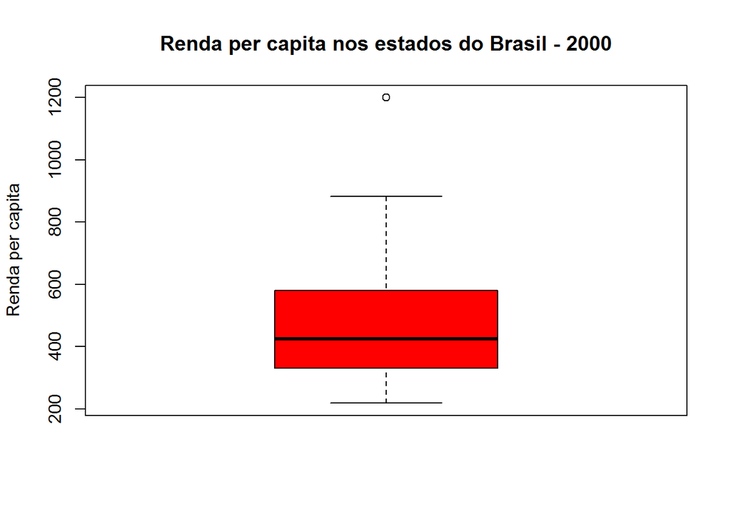

```r
boxplot(bs2$rdpc[bs2$ano==2000],col = "Red",main = "Renda per capita nos estados do Brasil - 2000",
        ylab = "Renda per capita")
```

```r
arrange(bs2[bs2$ano==2000,c(3,90)],desc(bs2$rdpc[bs2$ano==2000]))[1:3,]
```

|  | ufn | rdpc |
| --- | --- | --- |
| 1 | Distrito Federal | 1199.44 |
| 2 | São Paulo | 882.40 |
| 3 | Rio de Janeiro | 826.04 |

```r
arrange(bs2[bs2$ano==2000,c(3,90)],bs2$rdpc[bs2$ano==2000])[1:3,]
```

|  | ufn | rdpc |
| --- | --- | --- |
| 1 | Maranhão | 218.27 |
| 2 | Piauí | 254.78 |
| 3 | Alagoas | 285.29 |

### 2010

```r
summary(bs2010$rdpc)
```

```
##    Min. 1st Qu.  Median    Mean 3rd Qu.    Max.
##   96.25  281.12  467.65  493.61  650.62 2043.74
```

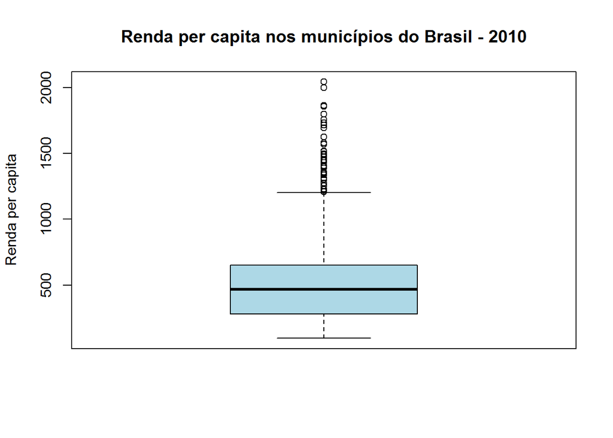

```r
boxplot(bs2010$rdpc,col="Light Blue",main = "Renda per capita nos municípios do Brasil - 2010",
        ylab = "Renda per capita")
```

```r
arrange(bs2010[,c(238,5,92)],desc(bs2010$rdpc))[1:3,]
```

|  | ufn | municipio | rdpc |
| --- | --- | --- | --- |
| 1 | São Paulo | SÃO CAETANO DO SUL | 2043.74 |
| 2 | Rio de Janeiro | NITERÓI | 2000.29 |
| 3 | Espírito Santo | VITÓRIA | 1866.58 |

```r
arrange(bs2010[,c(238,5,92)],bs2010$rdpc)[1:3,]
```

|  | ufn | municipio | rdpc |
| --- | --- | --- | --- |
| 1 | Maranhão | MARAJÁ DO SENA | 96.25 |
| 2 | Maranhão | FERNANDO FALCÃO | 106.99 |
| 3 | Maranhão | BELÁGUA | 107.14 |

```r
summary(bs2$rdpc[bs2$ano==2010])
```

```
##    Min. 1st Qu.  Median    Mean 3rd Qu.    Max.
##   360.3   509.4   599.0   697.0   813.2  1715.1
```

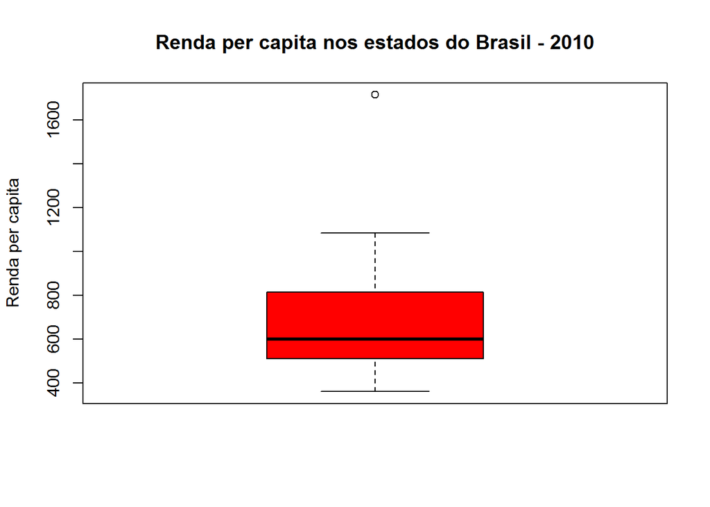

```r
boxplot(bs2$rdpc[bs2$ano==2010],col = "Red",main = "Renda per capita nos estados do Brasil - 2010",
        ylab = "Renda per capita")
```

```r
arrange(bs2[bs2$ano==2010,c(3,90)],desc(bs2$rdpc[bs2$ano==2010]))[1:3,]
```

|  | ufn | rdpc |
| --- | --- | --- |
| 1 | Distrito Federal | 1715.11 |
| 2 | São Paulo | 1084.46 |
| 3 | Rio de Janeiro | 1039.30 |

```r
arrange(bs2[bs2$ano==2010,c(3,90)],bs2$rdpc[bs2$ano==2010])[1:3,]
```

|  | ufn | rdpc |
| --- | --- | --- |
| 1 | Maranhão | 360.34 |
| 2 | Piauí | 416.93 |
| 3 | Alagoas | 432.56 |

Os grandes centros econômicos (São Paulo, Rio de Janeiro, Distrito Federal e Região Sul) se destacam por garantirem maiores salários. As cidades de região Nordeste apresentaram aumento nos salários ao longo destes 20 anos, mas ainda têm uma renda per capita baixa em relação às cidades das outras regiões do país.

## População com AGUA ENCANADA

### 1991

```r
summary(bs1991$t_agua)
```

```
##    Min. 1st Qu.  Median    Mean 3rd Qu.    Max.
##    0.00   22.69   57.29   53.39   83.44  100.00
```

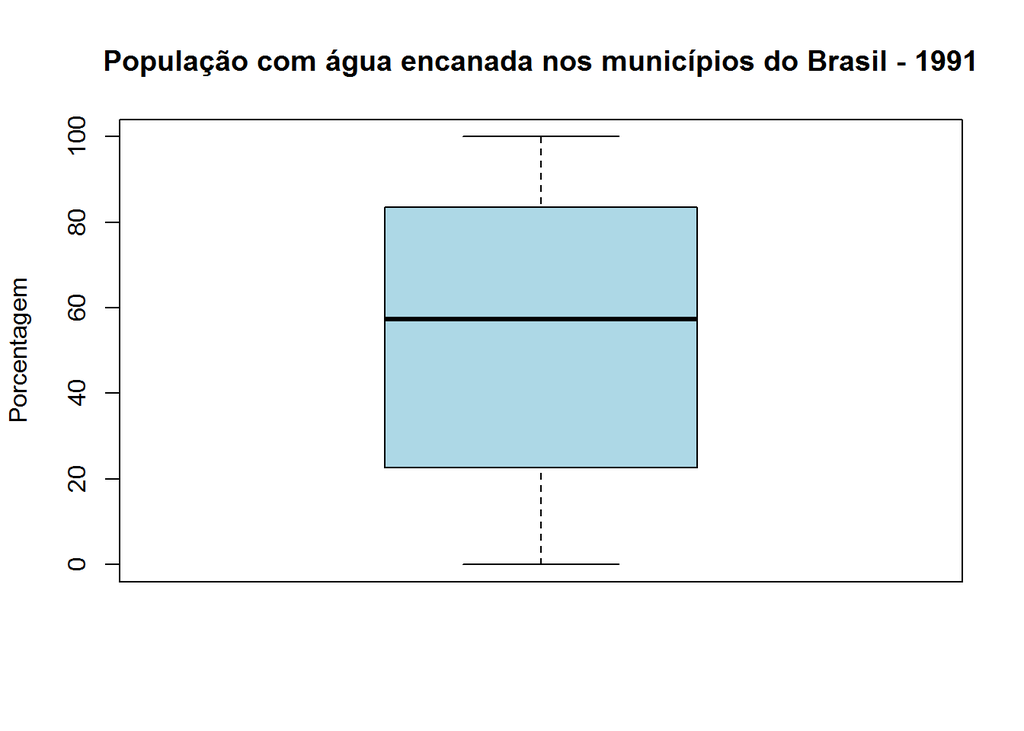

```r
boxplot(bs1991$t_agua,col="Light Blue",main = "População com água encanada nos municípios do Brasil - 1991",
        ylab = "Porcentagem")
```

```r
arrange(bs1991[,c(238,5,139)],desc(bs1991$t_agua))[1:3,]
```

|  | ufn | municipio | t_agua |
| --- | --- | --- | --- |
| 1 | São Paulo | ÁGUAS DE SÃO PEDRO | 100 |
| 2 | Santa Catarina | COCAL DO SUL | 100 |
| 3 | Santa Catarina | PAULO LOPES | 100 |

```r
arrange(bs1991[,c(238,5,139)],bs1991$t_agua)[1:3,]
```

|  | ufn | municipio | t_agua |
| --- | --- | --- | --- |
| 1 | Rondônia | BURITIS | 0 |
| 2 | Acre | SANTA ROSA DO PURUS | 0 |
| 3 | Pará | NOVA ESPERANÇA DO PIRIÁ | 0 |

```r
summary(bs2$t_agua[bs2$ano==1991])
```

```
##    Min. 1st Qu.  Median    Mean 3rd Qu.    Max.
##   25.12   43.28   55.94   58.92   79.05   95.59
```

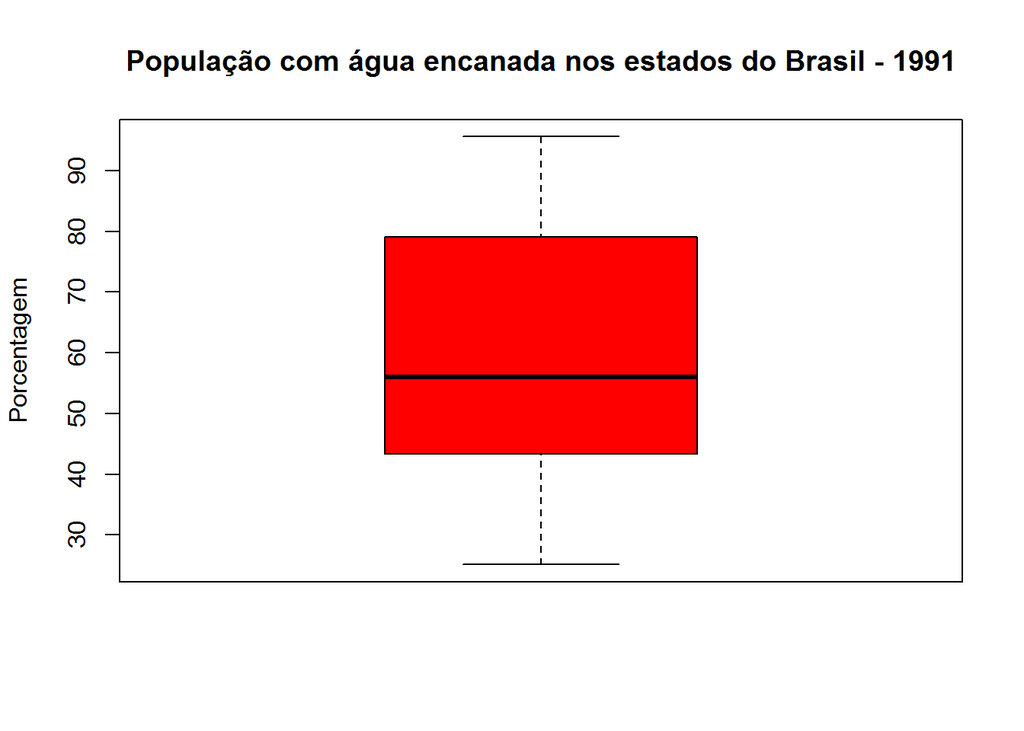

```r
boxplot(bs2$t_agua[bs2$ano==1991],col = "Red",main = "População com água encanada nos estados do Brasil - 1991",
        ylab = "Porcentagem")
```

```r
arrange(bs2[bs2$ano==1991,c(3,137)],desc(bs2$t_agua[bs2$ano==1991]))[1:3,]
```

|  | ufn | t_agua |
| --- | --- | --- |
| 1 | São Paulo | 95.59 |
| 2 | Rio de Janeiro | 90.87 |
| 3 | Santa Catarina | 90.41 |

```r
arrange(bs2[bs2$ano==1991,c(3,137)],bs2$t_agua[bs2$ano==1991])[1:3,]
```

|  | ufn | t_agua |
| --- | --- | --- |
| 1 | Maranhão | 25.12 |
| 2 | Acre | 28.69 |
| 3 | Tocantins | 28.97 |

### 2000

```r
summary(bs2000$t_agua)
```

```
##    Min. 1st Qu.  Median    Mean 3rd Qu.    Max.
##    0.00   41.69   76.21   66.67   93.48  100.00
```

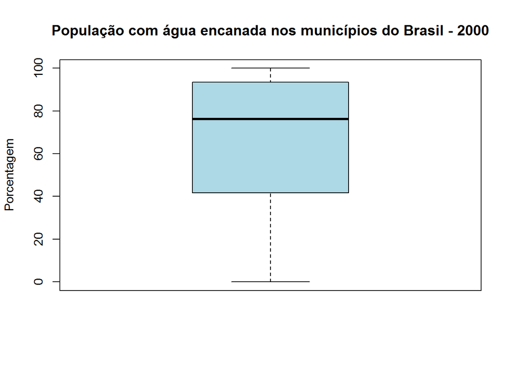

```r
boxplot(bs2000$t_agua,col="Light Blue",main = "População com água encanada nos municípios do Brasil - 2000",
        ylab = "Porcentagem")
```

```r
arrange(bs2000[,c(238,5,139)],desc(bs2000$t_agua))[1:3,]
```

|  | ufn | municipio | t_agua |
| --- | --- | --- | --- |
| 1 | São Paulo | ÁGUAS DE SÃO PEDRO | 100.00 |
| 2 | Paraná | INAJÁ | 100.00 |
| 3 | São Paulo | SANTA GERTRUDES | 99.98 |

```r
arrange(bs2000[,c(238,5,139)],bs2000$t_agua)[1:3,]
```

|  | ufn | municipio | t_agua |
| --- | --- | --- | --- |
| 1 | Piauí | BETÂNIA DO PIAUÍ | 0 |
| 2 | Piauí | GUARIBAS | 0 |
| 3 | Piauí | MASSAPÊ DO PIAUÍ | 0 |

```r
summary(bs2$t_agua[bs2$ano==2000])
```

```
##    Min. 1st Qu.  Median    Mean 3rd Qu.    Max.
##   33.09   59.60   66.77   70.68   90.69   97.30
```

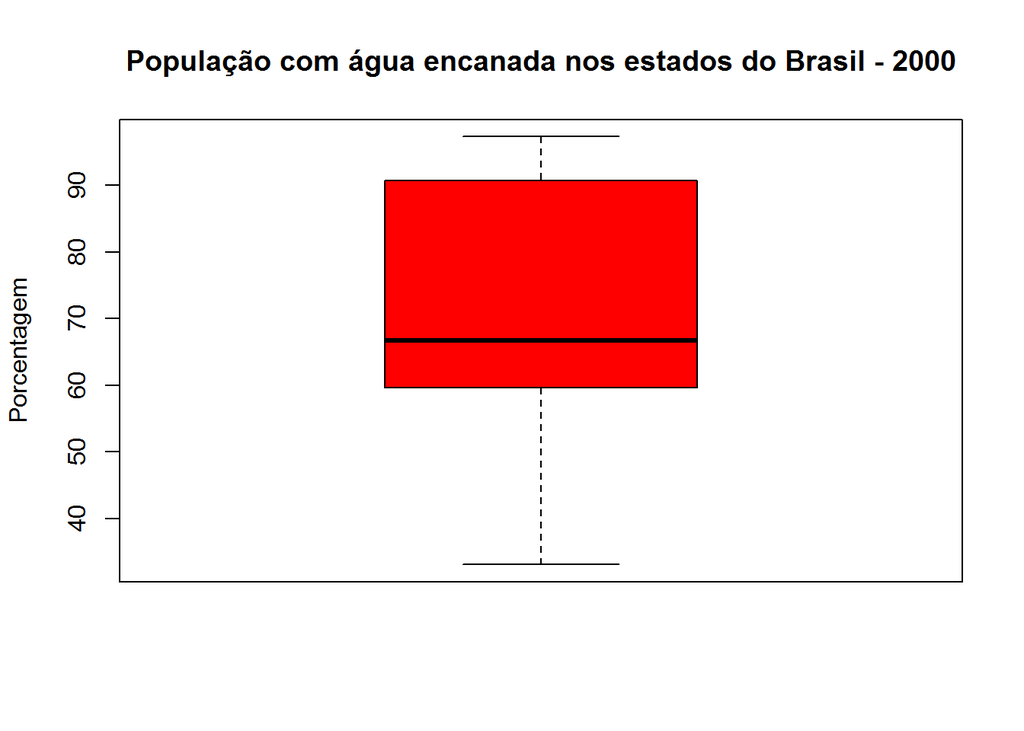

```r
boxplot(bs2$t_agua[bs2$ano==2000],col = "Red",main = "População com água encanada nos estados do Brasil - 2000",
        ylab = "Porcentagem")
```

```r
arrange(bs2[bs2$ano==2000,c(3,137)],desc(bs2$t_agua[bs2$ano==2000]))[1:3,]
```

|  | ufn | t_agua |
| --- | --- | --- |
| 1 | São Paulo | 97.30 |
| 2 | Paraná | 94.40 |
| 3 | Santa Catarina | 94.39 |

```r
arrange(bs2[bs2$ano==2000,c(3,137)],bs2$t_agua[bs2$ano==2000])[1:3,]
```

|  | ufn | t_agua |
| --- | --- | --- |
| 1 | Maranhão | 33.09 |
| 2 | Acre | 36.87 |
| 3 | Pará | 45.66 |

### 2010

```r
summary(bs2010$t_agua)
```

```
##    Min. 1st Qu.  Median    Mean 3rd Qu.    Max.
##    0.15   79.65   90.28   85.60   96.26  100.00
```

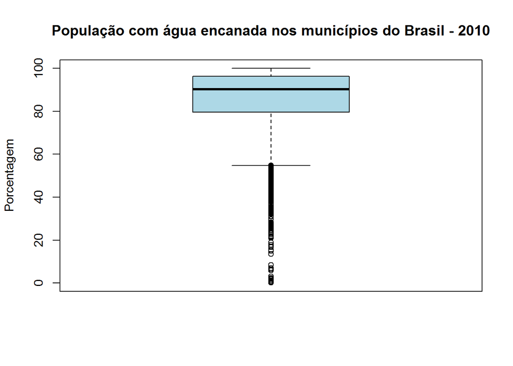

```r
boxplot(bs2010$t_agua,col="Light Blue",main = "População com água encanada nos municípios do Brasil - 2010",
        ylab = "Porcentagem")
```

```r
arrange(bs2010[,c(238,5,139)],desc(bs2010$t_agua))[1:3,]
```

|  | ufn | municipio | t_agua |
| --- | --- | --- | --- |
| 1 | Minas Gerais | Araporã | 100 |
| 2 | São Paulo | ÁGUAS DE SÃO PEDRO | 100 |
| 3 | São Paulo | DIRCE REIS | 100 |

```r
arrange(bs2010[,c(238,5,139)],bs2010$t_agua)[1:3,]
```

|  | ufn | municipio | t_agua |
| --- | --- | --- | --- |
| 1 | Paraíba | BARAÚNA | 0.15 |
| 2 | Piauí | MARCOLÂNDIA | 0.50 |
| 3 | Paraíba | ASSUNÇÃO | 0.77 |

```r
summary(bs2$t_agua[bs2$ano==2010])
```

```
##    Min. 1st Qu.  Median    Mean 3rd Qu.    Max.
##   77.32   85.18   93.35   90.31   96.00   98.57
```

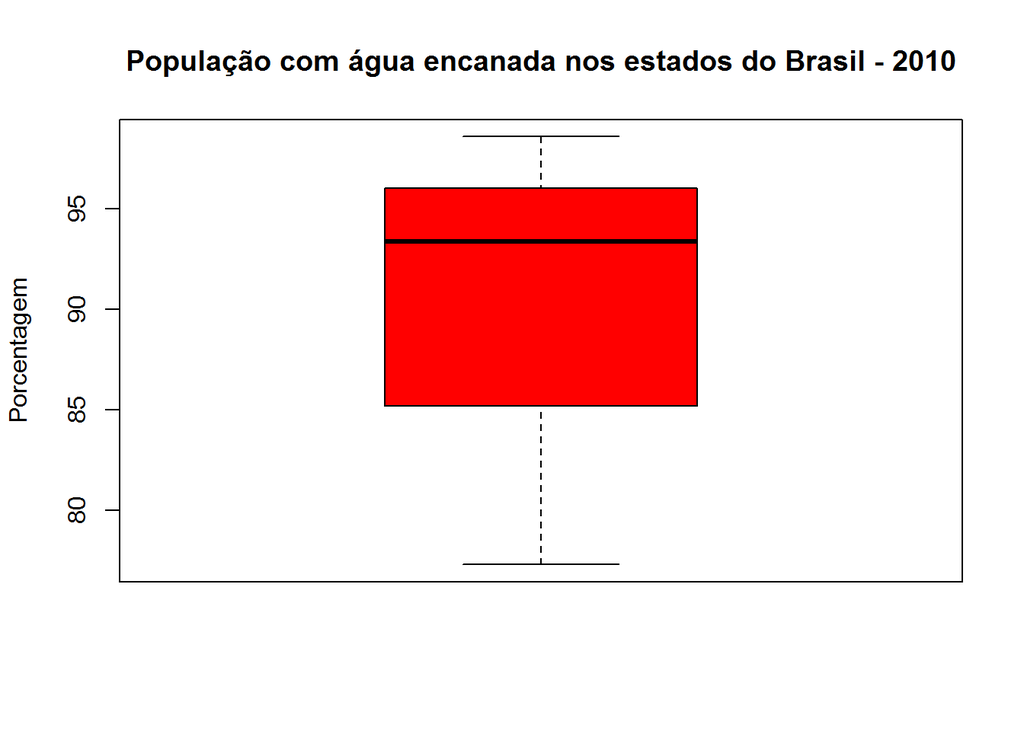

```r
boxplot(bs2$t_agua[bs2$ano==2010],col = "Red",main = "População com água encanada nos estados do Brasil - 2010",
        ylab = "Porcentagem")
```

```r
arrange(bs2[bs2$ano==2010,c(3,137)],desc(bs2$t_agua[bs2$ano==2010]))[1:3,]
```

|  | ufn | t_agua |
| --- | --- | --- |
| 1 | São Paulo | 98.57 |
| 2 | Distrito Federal | 98.13 |
| 3 | Goiás | 96.76 |

```r
arrange(bs2[bs2$ano==2010,c(3,137)],bs2$t_agua[bs2$ano==2010])[1:3,]
```

|  | ufn | t_agua |
| --- | --- | --- |
| 1 | Amazonas | 77.32 |
| 2 | Alagoas | 77.56 |
| 3 | Piauí | 81.60 |

Como as outras variáveis, houve evolução ao longo do tempo, as cidades do centro-Sul tem os melhores índices e as do Nordeste, os piores.

# Maiores IDH municipais em 2010

| municipio | ufn | idhm |
| --- | --- | --- |
| SÃO CAETANO DO SUL | São Paulo | 0.862 |
| ÁGUAS DE SÃO PEDRO | São Paulo | 0.854 |
| FLORIANÓPOLIS | Santa Catarina | 0.847 |
| VITÓRIA | Espírito Santo | 0.845 |
| BALNEÁRIO CAMBORIÚ | Santa Catarina | 0.845 |
| SANTOS | São Paulo | 0.840 |
| NITERÓI | Rio de Janeiro | 0.837 |
| JOAÇABA | Santa Catarina | 0.827 |
| BRASÍLIA | Distrito Federal | 0.824 |
| CURITIBA | Paraná | 0.823 |

[output cut: 29 more lines]

| ufn | n |
| --- | --- |
| Distrito Federal | 1 |
| Espírito Santo | 1 |
| Minas Gerais | 2 |
| Paraná | 2 |
| Rio de Janeiro | 1 |
| Rio Grande do Sul | 1 |
| Santa Catarina | 10 |
| São Paulo | 21 |

Pode-se perceber que, das 39 cidades com IDHM acima de 0.8, apenas uma está fora das regiões Sudeste e Sul, sendo esta Brasília. Das demais 38 cidades, vinte e uma estão em São Paulo e dez estão em Santa Catarina.

# Unidade federativa com menor expectativa de vida média, ponderada pela população dos municípios em 2000.

| ufn | evd_pond_est |
| --- | --- |
| Maranhão | 63.87541 |
| Alagoas | 64.31662 |
| Paraíba | 65.24831 |
| Piauí | 65.48743 |
| Sergipe | 65.56026 |
| Bahia | 65.70129 |
| Tocantins | 66.80394 |
| Rondônia | 67.30235 |
| Amazonas | 67.37700 |
| Acre | 67.39786 |

[output cut: 17 more lines]

O Maranhão é a unidade federativa com menor expectativa de vida média, ponderada pela população dos municípios em 2000. Essa espectativa é de 63.9 anos.

# Municípios outliers com relação ao índice de Gini em 1991 e em 2010

| municipio | ufn | gini |
| --- | --- | --- |
| SANTA HELENA | Paraíba | 0.92 |
| IPUAÇU | Santa Catarina | 0.87 |
| UIRAMUTÃ | Roraima | 0.86 |
| URANDI | Bahia | 0.86 |
| Tumiritinga | Minas Gerais | 0.85 |
| CAMPO ALEGRE DE LOURDES | Bahia | 0.84 |
| CAROEBE | Roraima | 0.83 |
| CURRAL DE CIMA | Paraíba | 0.83 |
| VALE VERDE | Rio Grande do Sul | 0.82 |
| NORMANDIA | Roraima | 0.81 |

[output cut: 85 more lines]

# Quantidade de municípios VS População acumulada desses municípios

## 1991

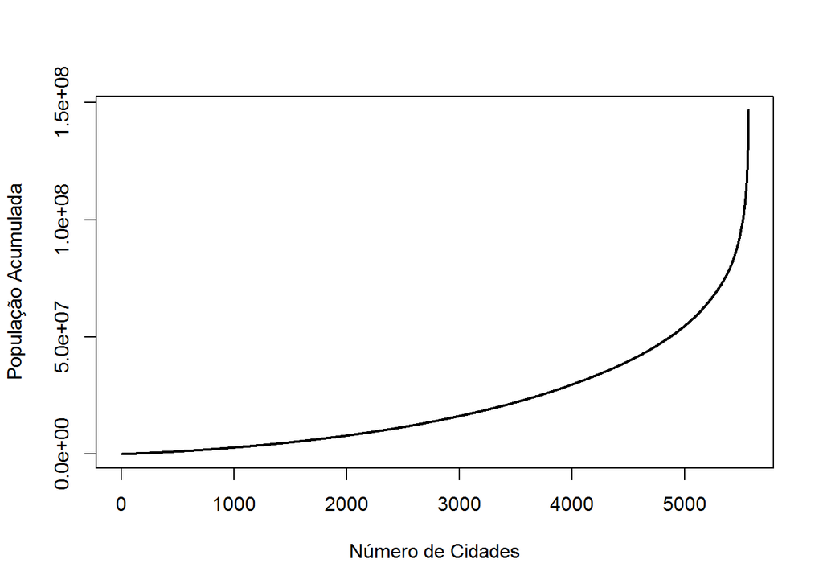

## 2000

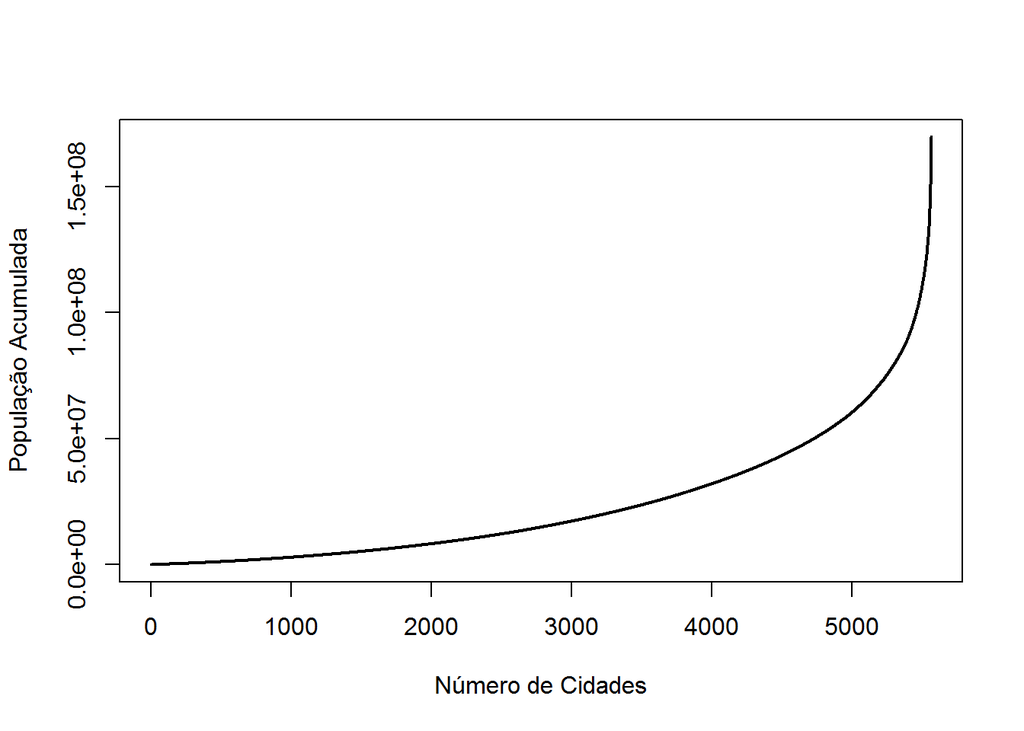

## 2010

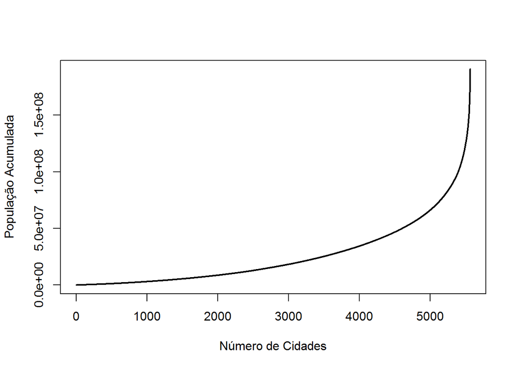

Nos três gráficos, pode-se perceber que, ordenando os múnicípios pelo tamanho da população, os municípios com grande população concentram boa parte da população. Isso pode ser comprovado pelo fato de que até os 5000 municípios menos populosos do país, a população acumulada não passava ou passava por pouco dos 50 milhões de habitantes.

# Associação Renda per capita e Expectativa de vida.

## 1991

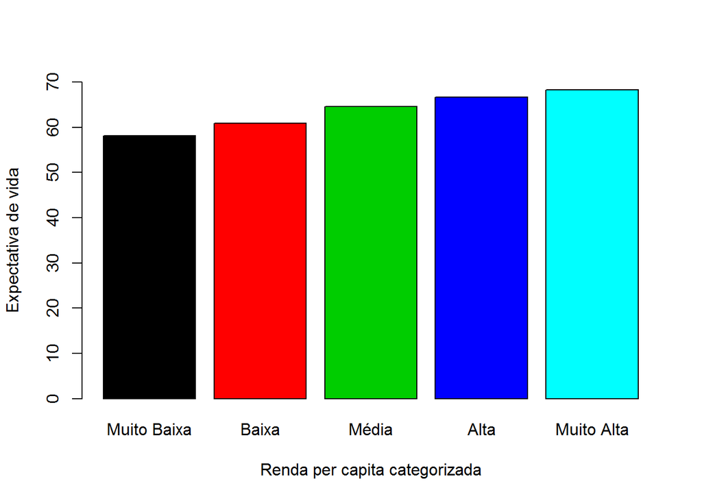

## 2000

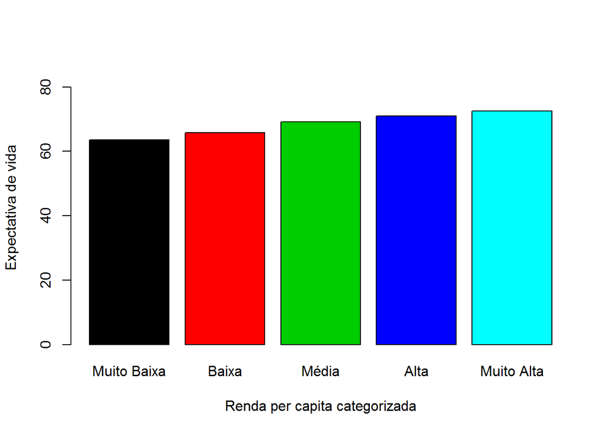

## 2010

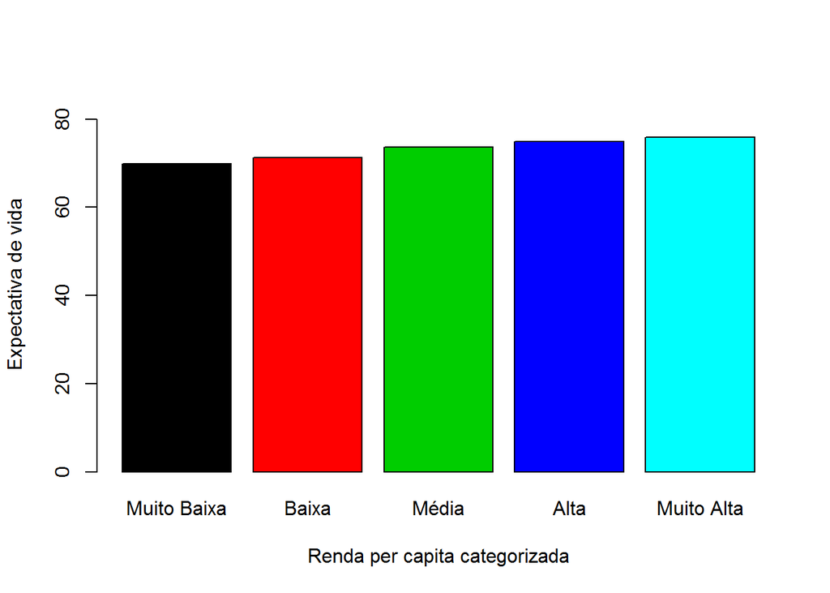

Ao longo dos anos, a renda per capita influencia em melhores condições de vida. As cidades com populações de maior renda per capita tendem a ter expectativas médias de vida mais altas em relação às cidades com populações de renda per capita média e baixa.

# No nordeste o aumento de distribuição de renda foi maior do que no sudeste?

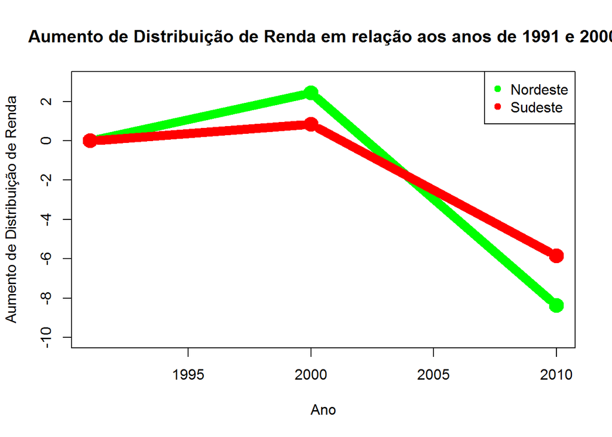

No Nordeste, entre os anos de 1991 a 2000, o aumento da distribuição de renda foi que o aumento da região Sudeste (a distribuição de renda na verdade ficou praticamente estável). Porém, entre os anos 2000 e 2010, o decréscimo da distribuição de renda na região Nordeste também foi maior em relação ao decréscimo da região Sudeste. Portanto, não se ode concluir que a região Nordeste teve um aumento de distribuição de renda maior que a Região Sudeste.